# Precipitant-stratified 30-day readmission after type 2 myocardial infarction

Nationwide Readmissions Database, 2018–2022 — statistical report

Author

Statistical analysis: Saad

Published

September 28, 2026

# 1 Provenance

Run provenance.

| Item | Value |
| --- | --- |
| Study | NRD_Saad_T2MI_Precip |
| Run at | 2026-09-28 02:35 |
| R version | R version 4.6.1 (2026-06-24 ucrt) |
| survey package | 4.5 |
| marginaleffects package | 1.0.0 |
| Platform | x86_64-w64-mingw32 |
| Data | HCUP Nationwide Readmissions Database 2018-2022 |

# 2 Methods summary

## 2.1 Cohort

Index admissions are **any-listed** type 2 myocardial infarction (ICD-10-CM **I21.A1**) among adults, discharged 2018–2022. I21.A1 is overwhelmingly a *secondary* diagnosis, which is the clinically correct picture for a supply–demand infarction, so the any-listed definition is mandatory; a principal-diagnosis-only cohort is sensitivity S5. The window starts in 2018 because I21.A1 became effective on 1 October 2017; 2016 has no I21.A1 records and 2017 has one quarter, which would manufacture a spurious trend. Project 1 reads only the 2018–2022 files and asserts that no other year is present.

Excluded: records also carrying **I21.A9** (other MI type) and records carrying **both** a type 1 and a type 2 code (uninterpretable as to which event drove the admission; 28,316 such records, reported as a finding in its own right).

**Type 1 versus type 2 comparison (secondary aim 2) — descriptive and explicitly NON-CAUSAL.** The type 1 comparator (any-listed I21.0–I21.4, I21.9 or I22.x without I21.A1, same years and exclusions, linked for 30-day readmission in the same pass) is used only to *describe* how the two coded populations differ. The two are not competing treatments, and no causal contrast is estimated or implied.

## 2.2 Exposure: the precipitant hierarchy

Eight mutually exclusive and exhaustive classes, assigned by a hierarchy **frozen before any result was seen** (SAP B3.2): (1) sepsis or severe infection; (2) acute GI bleed or blood-loss anaemia; (3) hypertensive emergency; (4) tachyarrhythmia; (5) acute respiratory failure; (6) hypovolaemia or non-cardiogenic shock; (7) perioperative; (8) none of the above. Ranks 1–6 are tested on the **principal diagnosis first**, then on any secondary diagnosis; rank 7 is procedure-based; rank 8 is the residual. The SAP asked for *present-on-admission-positive* secondary diagnoses; **no NRD file carries a POA indicator**, so all secondary diagnoses are used and a complication that arose after admission cannot be distinguished from a precipitant (a stated limitation). Reference class: **Sepsis or severe infection**.

**ImportantDefinitional decisions a cardiologist reviewer will check**

**Cardiogenic shock (R57.0) is not a precipitant.** It is a consequence of the infarction and is entered as a covariate.

**Hypertensive emergency is I16.1 and I16.9 only.** I16.0 is hypertensive *urgency* and is never a precipitant in any rank (including rank 7, which is procedure-based); 39,889 index admissions carry I16.0 and are reported only as a count.

**Perioperative = an ICD-10-PCS Section 0 (Medical and Surgical) procedure with approach 0 (open) or 4 (percutaneous endoscopic).** Neither the NRD nor the AHRQ PRCCSR file carries an operating-room flag. The received rule also admitted natural-opening approaches (7/8/F), which capture bedside urinary catheters, feeding tubes, intubation and diagnostic endoscopy; under that rule 22,674 admissions would be perioperative versus 11,533 under the rule used (Table S0b).

The raw co-occurrence of the classes *before* the hierarchy is Table S1b.

## 2.3 Outcome, design and estimation

Thirty-day all-cause readmission, linked within calendar year; December discharges, in-hospital deaths and transfers out are excluded from the index cohort. Design-based throughout: `DISCWT` weights, year-unique strata and clusters integer-coded, the design built **once** on the full cohort and every analysis a `subset()` of it; singleton strata centred. Primary model: survey-weighted logistic regression with age as a restricted cubic spline; the precipitant block is tested **jointly first**, then seven pairwise contrasts versus sepsis. Adjusted absolute risks by g-computation with delta-method intervals; overlap weighting (ATO), applied pairwise, is the co-estimator. Costs in 2022 US dollars using CPI-U, All Items, U.S. city average, not seasonally adjusted, annual average (CUUR0000SA0). Nothing representing 1–10 unweighted discharges is reported, and complementary suppression prevents recovery by subtraction (Section 16).

The following declared factor levels had no observations in the analytic cohort and were dropped before modelling, so that they could not appear as silent NA coefficients: Hospital bed size: Missing/other; Hospital location and teaching status: Missing/other; Hospital ownership: Missing/other. No reference category was affected.

The Nationwide Readmissions Database contains de-identified, publicly available administrative data and this analysis was therefore determined to be non-human-subjects research and exempt from institutional review board review. The HCUP Data Use Agreement was executed before any data were accessed.

# 3 Cohort construction

Table S0. Attrition from all NRD discharges to the analytic cohort (any step excluding 1-10 records is merged with its neighbour).

| Step | Cohort definition step | Unweighted discharges remaining | Excluded at this step |
| --- | --- | --- | --- |
| 0 | All NRD discharges, 2018-2022 | 85,834,822 |  |
| 1 | Any-listed type 2 myocardial infarction (I21.A1) | 1,126,920 | 84,707,902 |
| 2 | Excluding records also carrying I21.A9 (other MI type) | 1,126,802 | 118 |
| 3 | Excluding records also carrying a type 1 MI code (I21.0-I21.4, I21.9, I22.x) | 1,098,486 | 28,316 |
| 4 | Age >= 18 years | 1,098,404 | 82 |
| 5 | Survived the index admission (DIED = 0) | 980,701 | 117,703 |
| 6 | Not transferred to another short-term hospital | 967,395 | 13,306 |
| 7 | Discharged in months 1-11 (complete 30-day follow-up window) | 871,157 | 96,238 |
| 8 | Linkable (NRD_VISITLINK, NRD_DAYSTOEVENT and LOS all recorded) | 871,136 | 21 |
| 9 | Complete on every primary-model covariate | 870,486 | 650 |

Table S0b. Counts quoted in the Results that are not attrition steps.

| Item | Unweighted N |
| --- | --- |
| Type 1 / type 2 overlap records (excluded at step 3) | 28,316 |
| I21.A9 co-coded type 2 records (excluded at step 2) | 118 |
| Index admissions carrying I16.0 hypertensive URGENCY (not a precipitant) | 39,889 |
| Index admissions with an operating-room procedure, primary rule (Section 0, approach 0/4) | 75,907 |
| Index admissions with a procedure under the received broad rule (approach 0/4/7/8/F) | 196,556 |
| Index admissions classed Perioperative, primary rule | 11,533 |
| Index admissions that would be classed Perioperative under the broad rule | 22,674 |
| Index admissions classed None of the above, primary rule | 187,923 |
| Index admissions that would be classed None of the above under the broad rule | 176,782 |
| Patients contributing more than one index admission in a year | 44,791 |

- **Type 2 MI index admissions (analytic cohort):** 870,486 unweighted, representing 1,527,575 weighted national admissions over the five years.
- **Followed by a 30-day readmission:** 175,312.
- **Type 1 MI comparator index admissions** (descriptive, non-causal secondary aim): 1,837,814.

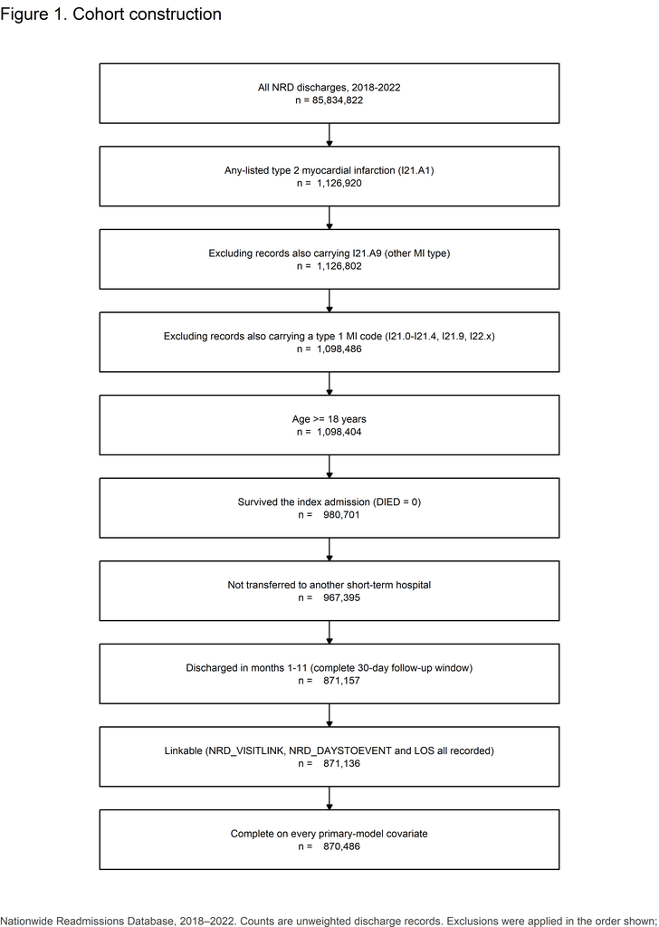

Figure 1. Cohort construction.

Table S1. Survey design properties.

| Property | Value |
| --- | --- |
| Unweighted index admissions | 870,486 |
| Weighted national index admissions | 1,527,575 |
| Strata (year x NRD_STRATUM) | 476 |
| Primary sampling units (year x HOSP_NRD) | 9,404 |
| Strata containing a single PSU | 5 |
| Design degrees of freedom | 8,928 |
| Critical value used for manually constructed intervals | t(8,928) = 1.960 |

Table S1a. All-listed I21.A1 per year: this build versus the HCUP frequency workbook.

| Year | HCUP frequency workbook, all-listed I21.A1 (unweighted) | This build, all-listed I21.A1 (unweighted) | Difference, % |
| --- | --- | --- | --- |
| 2018 | 1.455e+05 | 1.455e+05 | 0 |
| 2019 | 1.796e+05 | 1.796e+05 | 0 |
| 2020 | 2.282e+05 | 2.282e+05 | 0 |
| 2021 | 2.693e+05 | 2.693e+05 | 0 |
| 2022 | 3.043e+05 | 3.043e+05 | 0 |

# 4 Table 1. Baseline characteristics

Table 1. Baseline characteristics of index type 2 myocardial infarction hospitalizations, by precipitating illness class.

| Characteristic | Overall (n = 870,486) | Sepsis or severe infection (n = 212,755) | Acute GI bleed or blood-loss anaemia (n = 67,482) | Hypertensive emergency (n = 47,196) | Tachyarrhythmia (n = 228,176) | Acute respiratory failure (n = 77,718) | Hypovolaemia or non-cardiogenic shock (n = 37,854) | Perioperative (n = 11,520) | None of the above (n = 187,785) | Maximum absolute SMD vs sepsis |
| --- | --- | --- | --- | --- | --- | --- | --- | --- | --- | --- |
| Age, years, mean (SD) | 70.4 (14.6) | 71.1 (14.3) | 72.7 (13.1) | 61.8 (16.0) | 74.3 (12.7) | 67.9 (14.9) | 70.2 (15.2) | 69.1 (14.2) | 67.4 (15.2) | 0.611 |
| Age group, % (unweighted n) |  |  |  |  |  |  |  |  |  | 0.571 |
| ≥65 years | 68.6% (604,348) | 71.5% (153,807) | 76.2% (51,816) | 44.4% (21,581) | 78.8% (181,114) | 61.9% (48,803) | 67.4% (25,876) | 65.5% (7,641) | 59.8% (113,710) |  |
| <65 years | 31.4% (266,138) | 28.5% (58,948) | 23.8% (15,666) | 55.6% (25,615) | 21.2% (47,062) | 38.1% (28,915) | 32.6% (11,978) | 34.5% (3,879) | 40.2% (74,075) |  |
| Sex, % (unweighted n) |  |  |  |  |  |  |  |  |  | 0.123 |
| Male | 52.9% (460,734) | 53.5% (113,970) | 54.9% (37,068) | 53.4% (25,066) | 55.4% (126,346) | 50.4% (39,067) | 47.4% (17,910) | 53.3% (6,147) | 50.6% (95,160) |  |
| Female | 47.1% (409,752) | 46.5% (98,785) | 45.1% (30,414) | 46.6% (22,130) | 44.6% (101,830) | 49.6% (38,651) | 52.6% (19,944) | 46.7% (5,373) | 49.4% (92,625) |  |
| Primary expected payer, % (unweighted n) |  |  |  |  |  |  |  |  |  | Suppressed |
| Medicare | 71.1% (620,855) | 74.2% (158,340) | 76.2% (51,614) | 51.8% (24,731) | 78.2% (178,592) | 65.9% (51,470) | 70.5% (26,789) | 69.2% (7,984) | 64.5% (121,335) |  |
| Private | 12.4% (105,510) | 11.3% (23,503) | 11.5% (7,595) | 16.7% (7,705) | 10.5% (23,442) | 14.5% (10,980) | 12.0% (4,478) | 14.3% (1,616) | 14.3% (26,191) |  |
| Medicaid | 11.2% (100,339) | 10.0% (21,774) | 7.9% (5,406) | 21.3% (10,211) | 7.3% (17,025) | 13.5% (10,692) | 12.1% (4,661) | 11.4% (1,363) | 15.0% (29,207) |  |
| Other/self-pay | <11 (suppressed) | 4.3% (8,866) | 4.3% (2,778) | 10.1% (4,456) | 4.0% (8,853) | 5.9% (4,408) | 5.3% (1,877) | <11 (suppressed) | 6.1% (10,735) |  |
| Missing/other | <11 (suppressed) | 0.1% (272) | 0.1% (89) | 0.2% (93) | 0.1% (264) | 0.2% (168) | 0.1% (49) | <11 (suppressed) | 0.2% (317) |  |
| Median household income quartile (patient ZIP code), % (unweighted n) |  |  |  |  |  |  |  |  |  | 0.245 |
| 0-25th percentile | 31.7% (260,173) | 29.7% (59,045) | 29.3% (18,718) | 41.3% (18,261) | 29.1% (62,476) | 32.8% (24,178) | 32.1% (11,379) | 30.7% (3,341) | 35.2% (62,775) |  |
| 26th to 50th percentile | 27.8% (235,425) | 28.1% (58,122) | 28.8% (18,763) | 25.3% (11,895) | 28.1% (62,116) | 28.6% (21,619) | 26.4% (9,798) | 28.7% (3,205) | 27.2% (49,907) |  |
| 51st to 75th percentile | 22.6% (202,538) | 23.2% (50,842) | 23.3% (16,112) | 19.9% (9,889) | 23.4% (54,706) | 22.7% (18,262) | 22.4% (8,709) | 22.4% (2,652) | 21.4% (41,366) |  |
| 76th to 100th percentile | 16.8% (162,350) | 17.9% (42,245) | 17.5% (13,120) | 12.4% (6,625) | 18.4% (46,339) | 14.8% (12,715) | 18.1% (7,586) | 17.1% (2,185) | 15.1% (31,535) |  |
| Missing/other | 1.1% (10,000) | 1.1% (2,501) | 1.1% (769) | 1.1% (526) | 1.1% (2,539) | 1.2% (944) | 1.0% (382) | 1.2% (137) | 1.1% (2,202) |  |
| Patient residence (NCHS urban-rural classification), % (unweighted n) |  |  |  |  |  |  |  |  |  | 0.216 |
| Central metro ≥1 million | 27.0% (257,916) | 27.1% (64,321) | 24.4% (18,049) | 37.1% (18,127) | 24.7% (62,440) | 25.1% (21,437) | 30.1% (12,450) | 26.0% (3,300) | 28.1% (57,792) |  |
| Fringe metro ≥1 million | 22.8% (197,984) | 23.6% (49,742) | 23.3% (15,740) | 20.5% (9,771) | 23.8% (54,368) | 21.5% (16,613) | 23.5% (8,849) | 22.8% (2,614) | 21.6% (40,287) |  |
| Metro 250,000-999,999 | 21.1% (182,713) | 20.9% (44,366) | 21.4% (14,532) | 20.7% (9,759) | 20.9% (47,478) | 22.3% (17,485) | 19.9% (7,469) | 21.0% (2,420) | 21.1% (39,204) |  |
| Metro 50,000-249,999 | 11.4% (96,214) | 11.0% (22,605) | 11.8% (7,779) | 9.1% (4,228) | 12.2% (27,239) | 11.9% (9,014) | 10.8% (3,903) | 11.5% (1,281) | 11.1% (20,165) |  |
| Micropolitan | 9.6% (73,357) | 9.6% (17,664) | 10.5% (6,409) | 6.5% (2,714) | 9.9% (19,832) | 10.3% (7,102) | 8.5% (2,835) | 9.6% (999) | 9.5% (15,802) |  |
| Other | 7.6% (56,143) | 7.3% (12,827) | 8.3% (4,745) | 5.1% (2,108) | 8.1% (15,619) | 8.2% (5,451) | 6.5% (2,031) | 8.5% (838) | 7.8% (12,524) |  |
| Missing/other | 0.6% (6,159) | 0.5% (1,230) | 0.3% (228) | 0.9% (489) | 0.4% (1,200) | 0.7% (616) | 0.7% (317) | 0.5% (68) | 0.9% (2,011) |  |
| Admission day, % (unweighted n) |  |  |  |  |  |  |  |  |  | 0.108 |
| Weekday (Mon-Fri) | 73.9% (643,193) | 72.6% (154,458) | 75.4% (50,908) | 74.0% (34,988) | 74.5% (169,964) | 72.7% (56,508) | 74.2% (28,078) | 77.3% (8,891) | 74.2% (139,398) |  |
| Weekend (Sat-Sun) | 26.1% (227,293) | 27.4% (58,297) | 24.6% (16,574) | 26.0% (12,208) | 25.5% (58,212) | 27.3% (21,210) | 25.8% (9,776) | 22.7% (2,629) | 25.8% (48,387) |  |

[output cut: 128 more lines]

Weighted percentages are design-based national estimates using the HCUP discharge weight; unweighted n is the actual NRD sample size. Continuous variables are reported as design-weighted mean (SD). Standardized mean differences are reported in place of p-values because with 870,486 observations every p-value would be <0.001 and would convey nothing about the magnitude of an imbalance. Because the exposure has eight levels there is no single standardized mean difference; the figure shown is the MAXIMUM absolute standardized mean difference across the seven pairwise comparisons against the reference class (sepsis or severe infection), and for a categorical variable it is the maximum across that variable’s levels as well. 42 of 46 characteristics show |SMD| >= 0.10: Age, years, mean (SD); Age group, % (unweighted n); Sex, % (unweighted n); Median household income quartile (patient ZIP code), % (unweighted n); Patient residence (NCHS urban-rural classification), % (unweighted n); Admission day, % (unweighted n); Admission type, % (unweighted n); Hospital bed size, % (unweighted n); Hospital location and teaching status, % (unweighted n); Hospital ownership, % (unweighted n); Type 2 MI coded as the principal diagnosis, % (unweighted n); Cardiogenic shock at index, % (unweighted n); Invasive mechanical ventilation at index, % (unweighted n); Chronic kidney disease stage, % (unweighted n); Dialysis dependence at index, % (unweighted n); Known coronary artery disease (I25.1x/I25.7x), % (unweighted n); Prior revascularization (Z95.1/Z95.5), % (unweighted n); Atrial fibrillation or flutter (I48), % (unweighted n); COVID-19 at index (U07.1), % (unweighted n); Elixhauser comorbidity count, mean (SD); Congestive heart failure, % (unweighted n); Valvular disease, % (unweighted n); Pulmonary circulation disorders, % (unweighted n); Peripheral vascular disorders, % (unweighted n); Hypertension, uncomplicated, % (unweighted n); Hypertension, complicated, % (unweighted n); Other neurological disorders, % (unweighted n); Chronic pulmonary disease, % (unweighted n); Diabetes, uncomplicated, % (unweighted n); Liver disease, % (unweighted n); Obesity, % (unweighted n); Weight loss, % (unweighted n); Coagulopathy, % (unweighted n); Metastatic cancer, % (unweighted n); Solid tumour without metastasis, % (unweighted n); Depression, % (unweighted n); Alcohol abuse, % (unweighted n); Drug abuse, % (unweighted n); Cardiac arrhythmias (excluded from the model by pre-specification), % (unweighted n); Fluid and electrolyte disorders (excluded from the model by pre-specification), % (unweighted n); Renal failure (excluded from the model by pre-specification), % (unweighted n); Blood loss anaemia (excluded from the model by pre-specification), % (unweighted n). The eight precipitant classes are mutually exclusive and exhaustive by construction and sum to the analytic cohort. The Elixhauser cardiac-arrhythmia, fluid-and-electrolyte, renal-failure and anaemia flags are shown here but were removed from every model by pre-specification, because each overlaps a precipitant class by construction; showing them lets the reader verify that argument rather than take it on trust. Any cell representing fewer than 11 unweighted discharges is suppressed in accordance with the HCUP Data Use Agreement.

## 4.1 Raw co-occurrence of the precipitant classes

Table S1b. Any-listed co-occurrence of the seven precipitant classes, BEFORE the hierarchy was applied.

| Class (any-listed) | n | % of cohort | Sepsis or severe infection | Acute GI bleed or blood-loss anaemia | Hypertensive emergency | Tachyarrhythmia | Acute respiratory failure | Hypovolaemia or non-cardiogenic shock | Perioperative |
| --- | --- | --- | --- | --- | --- | --- | --- | --- | --- |
| Sepsis or severe infection | 215,055 | 24.7% | — | 25,147 (11.7%) | 4,818 (2.2%) | 85,543 (39.8%) | 91,466 (42.5%) | 49,158 (22.9%) | 25,220 (11.7%) |
| Acute GI bleed or blood-loss anaemia | 94,872 | 10.9% | 25,147 (26.5%) | — | 2,374 (2.5%) | 41,055 (43.3%) | 26,993 (28.5%) | 23,784 (25.1%) | 22,190 (23.4%) |
| Hypertensive emergency | 55,312 | 6.4% | 4,818 (8.7%) | 2,374 (4.3%) | — | 12,008 (21.7%) | 16,252 (29.4%) | 3,911 (7.1%) | 2,932 (5.3%) |
| Tachyarrhythmia | 355,329 | 40.8% | 85,543 (24.1%) | 41,055 (11.6%) | 12,008 (3.4%) | — | 93,013 (26.2%) | 56,409 (15.9%) | 34,836 (9.8%) |
| Acute respiratory failure | 237,161 | 27.2% | 91,466 (38.6%) | 26,993 (11.4%) | 16,252 (6.9%) | 93,013 (39.2%) | — | 37,091 (15.6%) | 23,969 (10.1%) |
| Hypovolaemia or non-cardiogenic shock | 142,169 | 16.3% | 49,158 (34.6%) | 23,784 (16.7%) | 3,911 (2.8%) | 56,409 (39.7%) | 37,091 (26.1%) | — | 13,794 (9.7%) |
| Perioperative | 75,825 | 8.7% | 25,220 (33.3%) | 22,190 (29.3%) | 2,932 (3.9%) | 34,836 (45.9%) | 23,969 (31.6%) | 13,794 (18.2%) | — |

Raw any-listed frequencies of the seven precipitant classes among index type 2 myocardial infarction admissions, computed BEFORE the pre-specified hierarchy was applied, so the rows are NOT mutually exclusive and the percentages do not sum to 100. Each off-diagonal cell is the number of admissions carrying both the row class and the column class, with the percentage taken over the row class. This table is published because it is the direct evidence for why a hierarchy is necessary at all: these conditions co-occur constantly, and any assignment rule must resolve that overlap. The hierarchy used is stated in full in the Methods and was frozen before any result was seen. Cells below 11 unweighted discharges are suppressed.

# 5 Table 2. Unadjusted outcomes

Table 2. Unadjusted outcomes of the index hospitalization, by precipitating illness class.

| Outcome | Overall | Sepsis or severe infection | Acute GI bleed or blood-loss anaemia | Hypertensive emergency | Tachyarrhythmia | Acute respiratory failure | Hypovolaemia or non-cardiogenic shock | Perioperative | None of the above |
| --- | --- | --- | --- | --- | --- | --- | --- | --- | --- |
| 30-day all-cause readmission, % (95% CI) [n] | 20.0% (19.9–20.2) [175,312] | 20.4% (20.2–20.6) [43,508] | 22.8% (22.4–23.1) [15,486] | 18.1% (17.7–18.5) [8,616] | 21.0% (20.7–21.2) [48,103] | 18.7% (18.4–19.0) [14,686] | 17.8% (17.4–18.2) [6,750] | 18.9% (18.1–19.7) [2,156] | 19.1% (18.8–19.3) [36,007] |
| Non-home discharge, % (95% CI) [n] | 29.5% (29.2–29.8) [256,101] | 43.7% (43.3–44.1) [92,554] | 33.3% (32.8–33.7) [22,358] | 16.6% (16.2–17.0) [7,881] | 26.3% (26.0–26.7) [59,500] | 25.8% (25.5–26.2) [20,010] | 30.8% (30.2–31.4) [11,640] | 31.8% (30.9–32.8) [3,675] | 20.5% (20.2–20.8) [38,483] |
| Discharge against medical advice, % (95% CI) [n] | 2.1% (2.0–2.2) [18,652] | 1.6% (1.6–1.7) [3,541] | 1.4% (1.3–1.5) [956] | 4.5% (4.3–4.8) [2,148] | 1.5% (1.4–1.5) [3,456] | 2.6% (2.5–2.8) [2,052] | 2.2% (2.0–2.4) [855] | 0.9% (0.7–1.1) [106] | 2.9% (2.7–3.0) [5,538] |
| Length of stay, days, median (IQR) | 5 (3–9) | 8 (5–14) | 7 (4–12) | 4 (2–6) | 5 (3–8) | 5 (3–9) | 4 (3–7) | 7 (4–12) | 4 (2–6) |
| Total cost, median (IQR), 2022 USD | $15,304 ($9,135–$27,961) | $23,111 ($13,720–$42,815) | $21,713 ($12,620–$42,112) | $12,447 ($7,856–$20,935) | $13,227 ($8,026–$23,575) | $16,482 ($9,997–$28,663) | $12,420 ($7,946–$20,458) | $30,238 ($20,433–$48,505) | $11,099 ($7,213–$17,626) |
| Total charges, median (IQR), 2022 USD | $61,294 ($33,700–$119,135) | $94,143 ($51,097–$184,890) | $87,512 ($46,840–$177,649) | $51,400 ($29,618–$93,206) | $52,145 ($29,112–$99,678) | $65,097 ($36,382–$121,002) | $49,764 ($28,659–$87,391) | $123,281 ($74,774–$211,795) | $44,353 ($26,415–$76,037) |

Table 2b. In-hospital mortality at the index admission, on the denominator that RETAINS in-hospital deaths (descriptive).

| Precipitant class | Unweighted n | Weighted N | In-hospital mortality, % (95% CI) | Deaths (unweighted) |
| --- | --- | --- | --- | --- |
| Overall | 976,130 | 1,710,446 | 10.6% (10.4–10.7) | 104,609 |
| Sepsis or severe infection | 277,040 | 480,966 | 22.8% (22.5–23.1) | 64,013 |
| Acute GI bleed or blood-loss anaemia | 73,710 | 130,138 | 8.3% (8.1–8.6) | 6,152 |
| Hypertensive emergency | 48,196 | 86,726 | 1.9% (1.8–2.1) | 955 |
| Tachyarrhythmia | 244,585 | 428,632 | 6.6% (6.4–6.7) | 16,152 |
| Acute respiratory failure | 89,016 | 158,224 | 12.5% (12.2–12.8) | 11,180 |
| Hypovolaemia or non-cardiogenic shock | 39,424 | 68,339 | 3.8% (3.6–4.0) | 1,519 |
| Perioperative | 11,804 | 20,488 | 2.3% (2.0–2.6) | 271 |
| None of the above | 192,355 | 336,933 | 2.3% (2.2–2.4) | 4,367 |

Table 2c. Process measures at the index admission (descriptive; not outcomes).

| Process measure at index | Overall | Sepsis or severe infection | Acute GI bleed or blood-loss anaemia | Hypertensive emergency | Tachyarrhythmia | Acute respiratory failure | Hypovolaemia or non-cardiogenic shock | Perioperative | None of the above |
| --- | --- | --- | --- | --- | --- | --- | --- | --- | --- |
| Coronary angiography or cardiac catheterization at index | 12.2% (103,424) | 6.1% (12,620) | 9.6% (6,316) | 16.4% (7,602) | 15.2% (33,923) | 11.9% (8,995) | 7.6% (2,800) | 17.3% (1,937) | 16.1% (29,231) |
| Percutaneous coronary intervention at index | 1.6% (13,784) | 1.0% (1,978) | 1.6% (1,069) | 2.3% (1,088) | 1.9% (4,280) | 1.6% (1,254) | 0.8% (307) | 1.9% (209) | 2.0% (3,599) |
| Coronary artery bypass grafting at index | <11 (suppressed) | 0.2% (382) | 2.0% (1,355) | 0.3% (126) | 0.3% (567) | 0.2% (120) | 0.1% (29) | 2.7% (303) | <11 (suppressed) |

Table 2d. Characteristics of the readmission hospitalization, among those readmitted.

| Outcome | Overall | Sepsis or severe infection | Acute GI bleed or blood-loss anaemia | Hypertensive emergency | Tachyarrhythmia | Acute respiratory failure | Hypovolaemia or non-cardiogenic shock | Perioperative | None of the above |
| --- | --- | --- | --- | --- | --- | --- | --- | --- | --- |
| Time from index discharge to readmission, days, median (IQR) | 11 (5–19) | 11 (5–19) | 11 (5–19) | 12 (5–20) | 11 (5–19) | 11 (5–19) | 11 (5–19) | 11 (5–18) | 11 (5–20) |
| Readmission length of stay, days, median (IQR) | 5 (3–8) | 5 (3–10) | 5 (3–9) | 4 (2–7) | 5 (3–8) | 4 (3–8) | 5 (3–8) | 5 (3–9) | 4 (2–8) |
| Unplanned (non-elective) readmission, % (95% CI) [n] | 95.4% (95.2–95.5) [167,646] | 96.1% (95.9–96.3) [41,929] | 94.5% (94.1–94.9) [14,690] | 96.3% (95.9–96.8) [8,321] | 95.1% (94.9–95.4) [45,868] | 95.0% (94.6–95.4) [13,992] | 96.0% (95.5–96.5) [6,494] | 93.4% (92.4–94.5) [2,019] | 95.1% (94.8–95.3) [34,333] |
| In-hospital death at readmission, % (95% CI) [n] | 8.6% (8.4–8.7) [15,303] | 10.2% (9.9–10.5) [4,574] | 8.6% (8.2–9.1) [1,363] | 3.6% (3.2–4.0) [315] | 9.2% (8.9–9.5) [4,469] | 8.6% (8.2–9.1) [1,301] | 8.0% (7.3–8.7) [549] | 7.6% (6.4–8.7) [171] | 7.0% (6.7–7.3) [2,561] |
| Readmission with a cardiac principal diagnosis, % (95% CI) [n] | 23.5% (23.2–23.8) [41,035] | 12.7% (12.4–13.1) [5,483] | 18.7% (18.0–19.3) [2,876] | 23.8% (22.8–24.8) [2,036] | 35.1% (34.6–35.5) [16,814] | 24.1% (23.4–24.9) [3,533] | 13.4% (12.5–14.3) [885] | 15.7% (14.1–17.4) [335] | 25.1% (24.6–25.6) [9,073] |
| Readmission cost, median (IQR), 2022 USD | $12,994 ($7,486–$24,611) | $14,662 ($8,451–$27,348) | $13,832 ($8,069–$25,982) | $11,360 ($6,673–$21,209) | $12,492 ($7,199–$23,687) | $12,833 ($7,383–$24,253) | $12,233 ($7,217–$22,393) | $14,123 ($7,948–$26,704) | $12,083 ($6,971–$22,817) |

All percentages are design-based national estimates with 95% confidence intervals from the survey design; the bracketed figure is the unweighted event count. Readmission, length of stay, cost and disposition are computed on the analytic cohort (discharge survivors with a complete 30-day window and a complete covariate vector). In-hospital mortality is computed on the larger denominator that RETAINS in-hospital deaths, because that is the only population on which a mortality rate is interpretable; the two denominators are reported separately and are never mixed. Readmission characteristics are computed on index admissions that were followed by a readmission and are therefore conditional on being readmitted. Coronary angiography, percutaneous coronary intervention and bypass grafting are reported as PROCESS MEASURES describing how coded type 2 myocardial infarction was managed; they are not outcomes and are not modelled as such. These are unadjusted comparisons; the adjusted estimates are in Table 3.

# 6 Table 3. Primary analysis

**ImportantThe omnibus test comes first**

Design-based joint Wald test across the whole eight-level precipitant block: F(7, 8855) = 92.44, p <0.001.

Table 3. Adjusted association between precipitating illness class and 30-day all-cause readmission, versus sepsis or severe infection.

| Precipitant class | Adjusted OR (95% CI) | p value | Adjusted risk difference, pp (95% CI) | Adjusted risk ratio (95% CI) |
| --- | --- | --- | --- | --- |
| Acute GI bleed or blood-loss anaemia | 1.12 (1.09–1.14) | <0.001 | 1.78 (1.39–2.16) | 1.09 (1.07–1.11) |
| Hypertensive emergency | 0.79 (0.77–0.82) | <0.001 | -3.39 (-3.80–-2.99) | 0.83 (0.81–0.85) |
| Tachyarrhythmia | 1.03 (1.02–1.05) | <0.001 | 0.51 (0.24–0.78) | 1.03 (1.01–1.04) |
| Acute respiratory failure | 0.88 (0.86–0.90) | <0.001 | -1.93 (-2.27–-1.59) | 0.91 (0.89–0.92) |
| Hypovolaemia or non-cardiogenic shock | 0.92 (0.89–0.95) | <0.001 | -1.31 (-1.78–-0.85) | 0.94 (0.91–0.96) |
| Perioperative | 0.94 (0.89–0.99) | 0.021 | -0.95 (-1.74–-0.15) | 0.95 (0.92–0.99) |
| None of the above | 0.93 (0.91–0.95) | <0.001 | -1.09 (-1.38–-0.79) | 0.95 (0.93–0.96) |

Table 3b. Adjusted absolute 30-day readmission risk for each precipitant class (marginal standardization).

| Precipitant class | Unweighted n | Adjusted 30-day readmission risk, % (95% CI) |
| --- | --- | --- |
| Sepsis or severe infection | 212,755 | 20.4% (20.2–20.6) |
| Acute GI bleed or blood-loss anaemia | 67,482 | 22.2% (21.9–22.5) |
| Hypertensive emergency | 47,196 | 17.0% (16.7–17.4) |
| Tachyarrhythmia | 228,176 | 20.9% (20.7–21.1) |
| Acute respiratory failure | 77,718 | 18.5% (18.2–18.8) |
| Hypovolaemia or non-cardiogenic shock | 37,854 | 19.1% (18.7–19.5) |
| Perioperative | 11,520 | 19.5% (18.7–20.3) |
| None of the above | 187,785 | 19.3% (19.1–19.6) |

Table 3c. Co-estimator: pairwise propensity-score overlap-weighted (ATO) odds ratio and risk difference versus sepsis.

| Precipitant class (vs sepsis) | Overlap-weighted OR (95% CI) | p value | Overlap-weighted RD, pp (95% CI) |
| --- | --- | --- | --- |
| Acute GI bleed or blood-loss anaemia | 1.12 (1.09–1.15) | <0.001 | 1.87 (1.47–2.27) |
| Hypertensive emergency | 0.78 (0.76–0.81) | <0.001 | -3.69 (-4.17–-3.21) |
| Tachyarrhythmia | 1.03 (1.01–1.05) | 0.002 | 0.44 (0.16–0.72) |
| Acute respiratory failure | 0.88 (0.86–0.90) | <0.001 | -2.01 (-2.37–-1.66) |
| Hypovolaemia or non-cardiogenic shock | 0.91 (0.88–0.93) | <0.001 | -1.48 (-1.94–-1.02) |
| Perioperative | 0.91 (0.86–0.96) | <0.001 | -1.41 (-2.22–-0.61) |
| None of the above | 0.94 (0.92–0.95) | <0.001 | -1.03 (-1.33–-0.72) |

Table 3d. Effective sample size and worst post-weighting covariate balance, by pair.

| Precipitant class (vs sepsis) | Unweighted n in the pair | Effective sample size after overlap weighting | Maximum absolute SMD after weighting |
| --- | --- | --- | --- |
| Acute GI bleed or blood-loss anaemia | 280,237 | 161,242 | 0.000 |
| Hypertensive emergency | 259,951 | 101,302 | 0.000 |
| Tachyarrhythmia | 440,931 | 317,433 | 0.000 |
| Acute respiratory failure | 290,473 | 184,076 | 0.000 |
| Hypovolaemia or non-cardiogenic shock | 250,609 | 105,168 | 0.000 |
| Perioperative | 224,275 | 35,826 | 0.000 |
| None of the above | 400,540 | 286,096 | 0.000 |

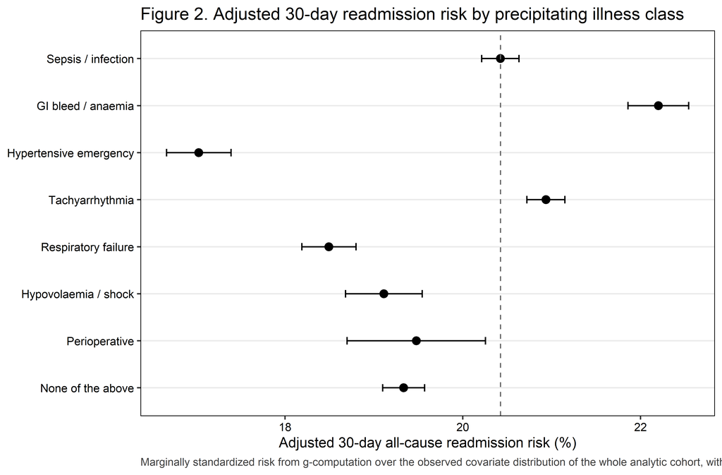

Figure 2. Adjusted 30-day readmission risk by precipitating illness class.

## 6.1 Sequential adjustment

Table 4. Sequential covariate adjustment, headline contrast and joint test. Model 4 is the adjusted estimate; Model 5 is OVER-ADJUSTED.

| Analysis | Joint Wald p (whole precipitant block) | Adjusted OR (95% CI) | p value | Adjusted risk difference, pp (95% CI) |
| --- | --- | --- | --- | --- |
| Model 1: unadjusted | <0.001 | 1.04 (1.02–1.05) | <0.001 | 0.58 (0.31–0.85) |
| Model 2: + demographic and administrative covariates | <0.001 | 1.06 (1.04–1.07) | <0.001 | 0.89 (0.62–1.16) |
| Model 3: + hospital covariates | <0.001 | 1.06 (1.04–1.07) | <0.001 | 0.90 (0.63–1.17) |
| Model 4: + comorbidity and clinical covariates (PRIMARY MODEL) | <0.001 | 1.03 (1.02–1.05) | <0.001 | 0.51 (0.24–0.78) |
| Model 5: OVER-ADJUSTED, not the adjusted estimate (+ length of stay, discharge disposition, AMA discharge) | <0.001 | 1.07 (1.05–1.08) | <0.001 | 1.00 (0.72–1.27) |

**Warning**

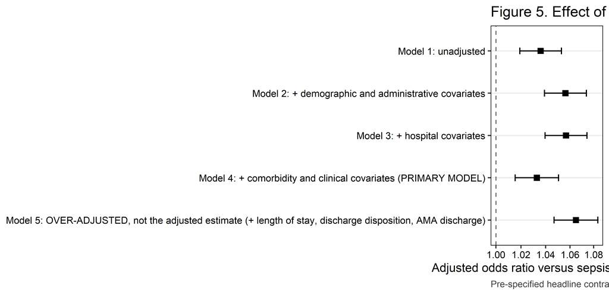

Figure 5. Sequential covariate adjustment.

## 6.2 Secondary outcomes

Table 4b. Secondary outcomes (one Benjamini-Hochberg family; q values over the estimable members).

| Secondary outcome | Events (unweighted) | Joint Wald p (precipitant block) | BH q value | Adjusted OR, Tachyarrhythmia vs Sepsis or severe infection (95% CI) |
| --- | --- | --- | --- | --- |
| Concordant readmission (same clinical domain as the index precipitant) | 24,394 | <0.001 | <0.001 | 0.19 (0.19–0.20) |
| Cardiac readmission (CCSR CIR009/CIR010/CIR011/CIR017/CIR019) | 41,035 | <0.001 | <0.001 | 2.47 (2.37–2.57) |
| Unplanned (non-elective) readmission | 167,646 | <0.001 | <0.001 | 0.97 (0.90–1.05) |
| In-hospital death at readmission | 15,303 | <0.001 | <0.001 | 0.94 (0.89–0.99) |
| Non-home discharge at index | 256,101 | <0.001 | <0.001 | 0.59 (0.58–0.60) |
| Discharge against medical advice at index | 18,652 | <0.001 | <0.001 | 1.06 (1.00–1.12) |

The **primary** outcome is not a member of this family: it is tested once, unadjusted.

## 6.3 Unmeasured confounding and cross-check

Table S5. E-values for each precipitant class, on the risk ratio scale.

| Precipitant class (vs sepsis) | Adjusted risk ratio (95% CI) | E-value, point estimate | E-value, CI limit nearest the null |
| --- | --- | --- | --- |
| Acute GI bleed or blood-loss anaemia | 1.09 (1.07–1.11) | 1.39 | 1.34 |
| Hypertensive emergency | 0.83 (0.81–0.85) | 1.69 | 1.62 |
| Tachyarrhythmia | 1.03 (1.01–1.04) | 1.19 | 1.12 |
| Acute respiratory failure | 0.91 (0.89–0.92) | 1.44 | 1.39 |
| Hypovolaemia or non-cardiogenic shock | 0.94 (0.91–0.96) | 1.34 | 1.26 |
| Perioperative | 0.95 (0.92–0.99) | 1.27 | 1.09 |
| None of the above | 0.95 (0.93–0.96) | 1.30 | 1.25 |

E-values are reported on the RISK RATIO scale, never on the odds ratio, which would overstate them. Each is the minimum strength of association, on the risk ratio scale, that an unmeasured confounder would need with both the precipitant class and 30-day readmission, above and beyond the measured covariates, to explain the observed contrast away. The most plausible such confounder here is ILLNESS SEVERITY: the NRD carries no vital signs, no laboratory values and no troponin concentration, and a sicker patient is both more likely to receive a given precipitant code and more likely to be readmitted.

Table S5b. Delta-method g-computation checked against marginaleffects::avg_comparisons().

| Quantity | svy_std_risk() | marginaleffects::avg_comparisons() | Absolute difference | Agreement |
| --- | --- | --- | --- | --- |
| Adjusted risk difference, Tachyarrhythmia vs Sepsis or severe infection (pp); maximum absolute difference over all seven contrasts in the last column | 0.5127 | 0.5127 | 0.000000 | AGREE (to three decimal places on the probability scale, all seven contrasts) |

# 7 Concordant readmission

**ImportantThe endpoint the paper is built on**

When a patient with a coded type 2 myocardial infarction is readmitted within 30 days, do they return with **their precipitant** or with a **cardiac** problem?

Table 5. Concordant versus cardiac readmission, by precipitating illness class.

| Precipitant class | Readmitted (unweighted n) | Concordant readmission, % of readmissions (n) | Cardiac readmission, % of readmissions (n) | Concordant readmission, % of ALL index admissions |
| --- | --- | --- | --- | --- |
| Sepsis or severe infection | 43,508 | 35.1% (15,503) | 12.7% (5,483) | 7.2% |
| Acute GI bleed or blood-loss anaemia | 15,486 | 11.1% (1,731) | 18.7% (2,876) | 2.5% |
| Hypertensive emergency | 8,616 | 11.4% (975) | 23.8% (2,036) | 2.1% |
| Tachyarrhythmia | 48,103 | 9.1% (4,329) | 35.1% (16,814) | 1.9% |
| Acute respiratory failure | 14,686 | 8.8% (1,281) | 24.1% (3,533) | 1.6% |
| Hypovolaemia or non-cardiogenic shock | 6,750 | 4.0% (270) | 13.4% (885) | 0.7% |
| Perioperative | 2,156 | 14.3% (305) | 15.7% (335) | 2.7% |
| None of the above | 36,007 | Not defined | 25.1% (9,073) | Not defined |

A readmission is CONCORDANT when the DXCCSR v2025.1 default category of its principal diagnosis falls in the same clinical domain as the precipitating illness class assigned at the index admission; the full class-to-category mapping was frozen before any result was seen and is reproduced in the supplement. A readmission is CARDIAC when that category is CIR009, CIR010, CIR011, CIR017 or CIR019. The two are not mutually exclusive: a tachyarrhythmia precipitant followed by a dysrhythmia readmission is both. The ‘none of the above’ class has no concordant set by construction and is scored as undefined rather than zero; 36,007 readmissions fall in that class and are excluded from the concordance column only. The third and fourth columns are conditional on being readmitted and answer ‘what did they come back with?’; the fifth column is the absolute risk of a concordant readmission among all index admissions in that class and is the quantity to quote alongside the overall readmission rate. Adjusted for the full primary covariate block, the design-based joint Wald test of whether concordance differs across precipitant classes gives p <0.001. Cells below 11 unweighted readmissions are suppressed under the HCUP Data Use Agreement.

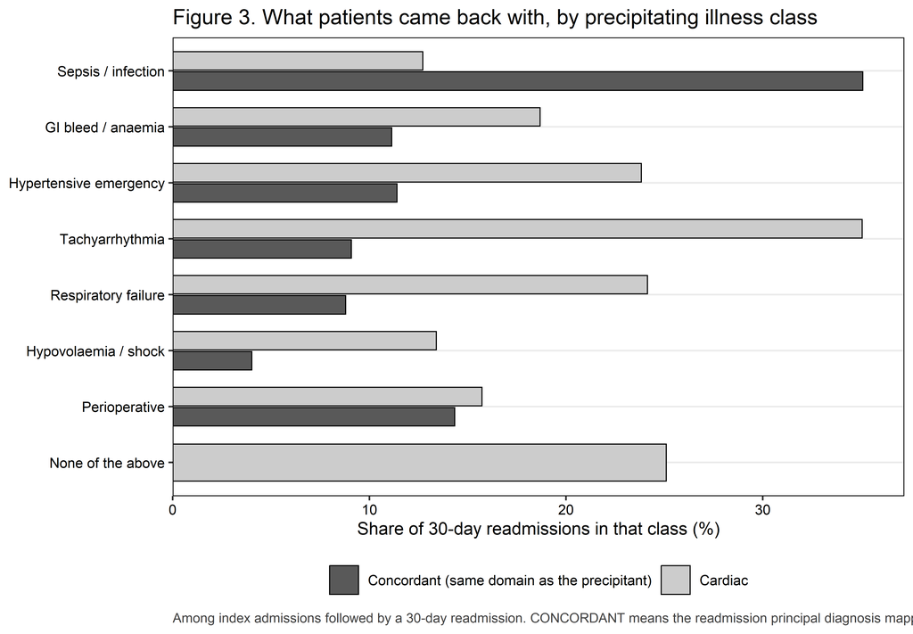

Figure 3. What patients came back with, by precipitating illness class.

# 8 Table 6. Cause of readmission

Table 6. Principal diagnosis category (DXCCSR v2025.1) of the first 30-day readmission.

| Cause of readmission (DXCCSR category) | Overall, % (n) | Sepsis or severe infection | Acute GI bleed or blood-loss anaemia | Hypertensive emergency | Tachyarrhythmia | Acute respiratory failure | Hypovolaemia or non-cardiogenic shock | Perioperative | None of the above | Joint Wald p | BH q value |
| --- | --- | --- | --- | --- | --- | --- | --- | --- | --- | --- | --- |
| Heart failure | 15.6% (27,283) | 8.8% ( 3,792) | 12.1% (1,867) | 15.5% (1,321) | 22.0% (10,582) | 18.3% (2,679) | 8.7% ( 572) | 9.2% (197) | 17.3% ( 6,273) | <0.001 | <0.001 |
| Septicemia | 13.5% (24,083) | 24.9% (11,086) | 10.0% (1,539) | 5.7% ( 492) | 10.1% ( 4,903) | 11.1% (1,648) | 13.4% ( 919) | 10.8% (240) | 8.9% ( 3,256) | <0.001 | <0.001 |
| Cardiac dysrhythmias | 3.5% ( 6,081) | 1.7% ( 749) | 2.2% ( 339) | 1.6% ( 142) | 8.8% ( 4,188) | 1.1% ( 161) | 1.0% ( 66) | 1.6% ( 34) | 1.2% ( 402) | <0.001 | <0.001 |
| Respiratory failure; insufficiency; arrest | 3.4% ( 5,875) | 3.3% ( 1,381) | 2.3% ( 342) | 2.9% ( 250) | 3.1% ( 1,445) | 6.0% ( 872) | 2.0% ( 138) | 2.1% ( 46) | 4.0% ( 1,401) | <0.001 | <0.001 |
| Acute and unspecified renal failure | 3.4% ( 5,851) | 3.3% ( 1,421) | 2.9% ( 442) | 4.0% ( 334) | 3.4% ( 1,594) | 2.9% ( 419) | 5.8% ( 385) | 2.8% ( 58) | 3.3% ( 1,198) | <0.001 | <0.001 |
| Acute myocardial infarction | 3.2% ( 5,628) | 1.6% ( 687) | 3.3% ( 503) | 4.7% ( 409) | 3.1% ( 1,496) | 3.4% ( 515) | 2.8% ( 186) | 3.6% ( 76) | 4.8% ( 1,756) | <0.001 | <0.001 |
| Chronic kidney disease | 3.2% ( 5,687) | 1.9% ( 843) | 2.6% ( 418) | 8.9% ( 788) | 2.7% ( 1,338) | 4.8% ( 728) | 1.2% ( 87) | 4.2% ( 91) | 3.8% ( 1,394) | <0.001 | <0.001 |
| Pneumonia (except that caused by tuberculosis) | 2.7% ( 4,539) | 3.1% ( 1,318) | 1.9% ( 291) | 1.5% ( 127) | 2.6% ( 1,202) | 3.6% ( 501) | 2.0% ( 130) | 2.6% ( 54) | 2.7% ( 916) | <0.001 | <0.001 |
| Gastrointestinal hemorrhage | 2.5% ( 4,468) | 2.4% ( 1,060) | 8.4% (1,306) | 1.2% ( 109) | 2.1% ( 982) | 1.7% ( 258) | 1.9% ( 128) | 2.3% ( 49) | 1.6% ( 576) | <0.001 | <0.001 |
| Diabetes mellitus with complication | 2.5% ( 4,364) | 2.6% ( 1,125) | 2.1% ( 335) | 3.0% ( 256) | 1.6% ( 758) | 2.3% ( 340) | 5.8% ( 387) | 5.0% (107) | 2.9% ( 1,056) | <0.001 | <0.001 |
| COVID-19 | 2.1% ( 3,696) | 1.9% ( 842) | 1.4% ( 206) | 1.5% ( 135) | 2.2% ( 1,052) | 3.6% ( 526) | 2.1% ( 134) | 1.2% ( 30) | 2.2% ( 771) | <0.001 | <0.001 |
| Fluid and electrolyte disorders | 1.9% ( 3,379) | 1.6% ( 691) | 1.4% ( 215) | 4.1% ( 355) | 1.6% ( 756) | 2.2% ( 322) | 2.8% ( 189) | 2.3% ( 44) | 2.3% ( 807) | <0.001 | <0.001 |
| Cerebral infarction | 1.7% ( 2,964) | 1.1% ( 478) | 1.5% ( 248) | 2.9% ( 249) | 1.8% ( 859) | 1.3% ( 192) | 1.7% ( 124) | 1.6% ( 35) | 2.2% ( 779) | <0.001 | <0.001 |
| Chronic obstructive pulmonary disease and bronchiectasis | 1.6% ( 2,766) | 1.0% ( 436) | 0.6% ( 90) | 1.0% ( 81) | 1.6% ( 742) | 2.6% ( 385) | 1.2% ( 88) | 0.6% ( 11) | 2.6% ( 933) | <0.001 | <0.001 |
| Complication of other surgical or medical care, injury, initial encounter | 1.5% ( 2,601) | 2.3% ( 1,013) | 2.7% ( 422) | 1.2% ( 93) | 0.9% ( 413) | 0.9% ( 137) | 1.3% ( 93) | 6.8% (145) | 0.8% ( 285) | <0.001 | <0.001 |
| Other | 37.7% (66,047) | 38.5% (16,586) | 44.7% (6,923) | 40.3% (3,475) | 32.8% (15,793) | 34.1% (5,003) | 46.2% (3,124) | 43.3% (939) | 39.4% (14,204) | <0.001 | — |

Based on 175,312 unweighted 30-day readmissions with a recorded principal diagnosis, mapped to the AHRQ DXCCSR v2025.1 default inpatient category. 123 readmission principal diagnosis code(s) had no default CCSR assignment and are grouped under ‘Other’. The top 15 categories by overall weighted share are reported; all remaining categories are folded into ‘Other’, as are 0 categories that fell below the 11 unweighted discharge threshold in at least one precipitant class. Percentages are within-class shares of all readmissions in that class and therefore sum to 100% down each column. P values are design-based JOINT Wald tests across the whole eight-level precipitant block from survey-weighted logistic regression of the category indicator, not pairwise comparisons; q values are Benjamini-Hochberg adjusted across the reported categories. This table is descriptive; the pre-specified concordance endpoint in Table 5 is the analysis that answers whether patients return with their own precipitant.

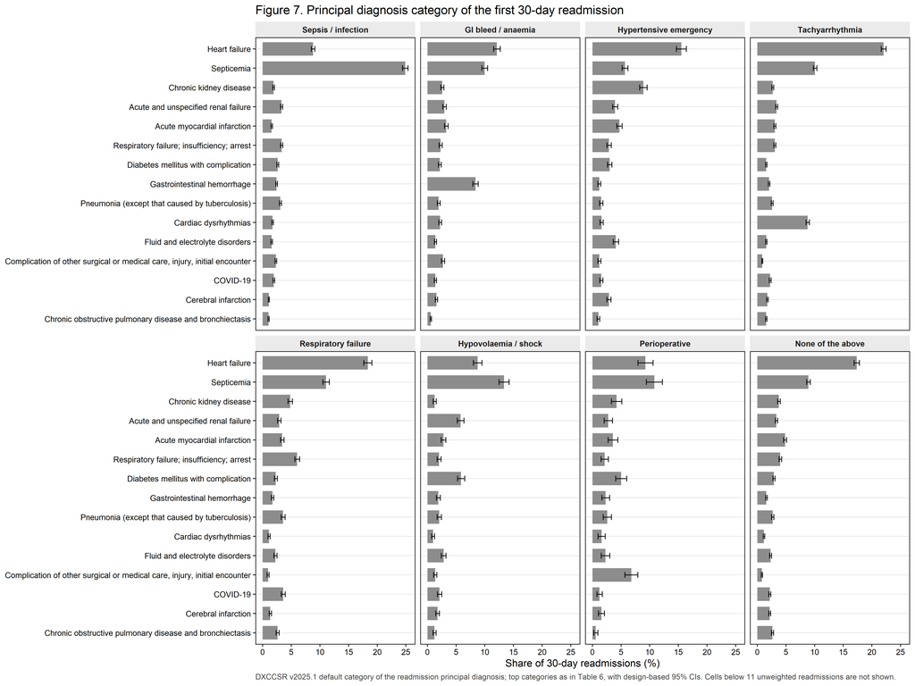

Figure 7. Cause of readmission by precipitating illness class, with design-based 95% CIs.

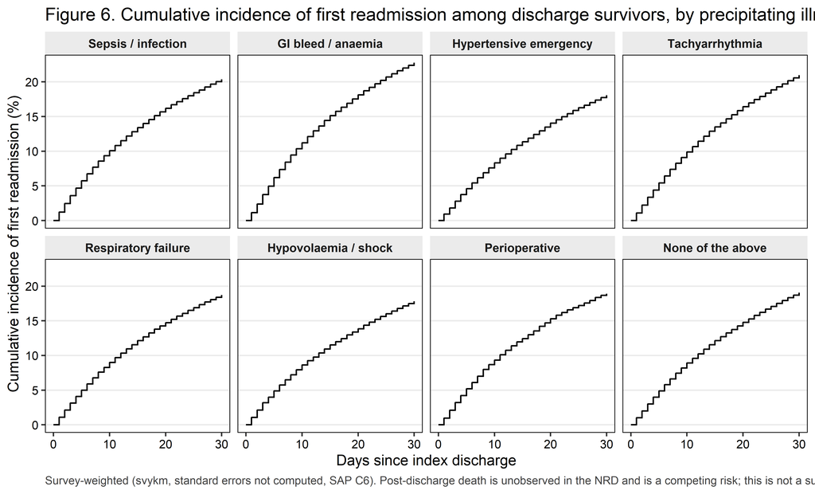

Figure 6. Cumulative incidence of first readmission among discharge survivors.

Table 6b. Numbers at risk for Figure 6 (unweighted).

| Precipitant class | At risk, day 0 | At risk, day 10 | At risk, day 20 | At risk, day 30 |
| --- | --- | --- | --- | --- |
| Sepsis or severe infection | 212,755 | 192,811 | 179,257 | 169,961 |
| Acute GI bleed or blood-loss anaemia | 67,482 | 60,412 | 55,552 | 52,259 |
| Hypertensive emergency | 47,196 | 43,537 | 40,750 | 38,738 |
| Tachyarrhythmia | 228,176 | 207,252 | 191,728 | 180,950 |
| Acute respiratory failure | 77,718 | 71,217 | 66,529 | 63,290 |
| Hypovolaemia or non-cardiogenic shock | 37,854 | 34,852 | 32,792 | 31,228 |
| Perioperative | 11,520 | 10,530 | 9,845 | 9,389 |
| None of the above | 187,785 | 172,291 | 160,834 | 152,475 |

# 9 Table 7. Type 2 versus type 1 myocardial infarction (descriptive, non-causal)

**WarningDescriptive and explicitly NON-CAUSAL**

Type 1 and type 2 myocardial infarction are not competing treatments. No patient could have been assigned to one rather than the other, and the ‘effect’ of being coded type 2 is not a quantity that exists. What follows is a case-mix-standardized **description** of how the two coded populations differ, and it must be described that way in the manuscript.

Table 7. Type 2 versus type 1 myocardial infarction: cohort characteristics and crude 30-day readmission. DESCRIPTIVE AND NON-CAUSAL.

| Myocardial infarction type | Unweighted n | Weighted N | Age, mean (SD) | Elixhauser count, mean | Crude 30-day readmission, % (95% CI) [readmissions] |
| --- | --- | --- | --- | --- | --- |
| Type 1 MI | 1,837,814 | 3,328,607 | 67.4 (13.5) | 4.4 | 14.8% (14.7–14.9) [273,682] |
| Type 2 MI | 871,136 | 1,528,841 | 70.4 (14.6) | 5.6 | 20.0% (19.9–20.2) [175,411] |

Table 7b. Case-mix-standardized description of type 2 versus type 1 MI. NON-CAUSAL: not an effect estimate.

| Quantity | Estimate |
| --- | --- |
| Case-mix-standardized DESCRIPTION (non-causal): type 2 vs type 1, odds ratio (95% CI) | 1.04 (1.03–1.05) |
| Case-mix-standardized DESCRIPTION (non-causal): type 2 minus type 1, risk difference, pp (95% CI) | 0.46 (0.33–0.59) |

# 10 Table 8. Exploratory subgroups

Table 8. Pre-specified subgroup analyses (EXPLORATORY; interaction tested on the whole block).

| Subgroup | Level | Unweighted n | Readmissions (unweighted) | Joint Wald p (precipitant block) | Adjusted OR, Tachyarrhythmia vs Sepsis or severe infection (95% CI) | Interaction p |
| --- | --- | --- | --- | --- | --- | --- |
| Overall (primary model) |  | 870,486 | 175,312 | <0.001 | 1.03 (1.02–1.05) |  |
| Age <65 vs ≥65 years | ≥65 years | 604,348 | 120,605 | <0.001 | 1.05 (1.03–1.07) | <0.001 |
|  | <65 years | 266,138 | 54,707 | <0.001 | 0.98 (0.95–1.02) |  |
| Chronic kidney disease vs none | No coded CKD | 512,297 | 87,523 | <0.001 | 1.00 (0.97–1.02) | <0.001 |
|  | Chronic kidney disease | 358,189 | 87,789 | <0.001 | 1.07 (1.04–1.10) |  |
| Pre-pandemic (2018-2019) vs pandemic (2020-2022) | Pre-pandemic (2018-2019) | 254,812 | 52,854 | <0.001 | 1.04 (1.00–1.07) | 0.063 |
|  | Pandemic (2020-2022) | 615,674 | 122,458 | <0.001 | 1.03 (1.01–1.05) |  |

ALL SUBGROUP RESULTS ARE EXPLORATORY and are not adjusted for multiplicity. Within each subgroup the primary model was refitted on the primary covariate block, and two quantities are reported: the design-based JOINT Wald test across the whole eight-level precipitant block, which is the substantive question in that subgroup, and the pre-specified headline contrast (Tachyarrhythmia versus Sepsis or severe infection), which is shown so that the direction of the association is visible. Effect modification is assessed by a design-based Wald test on the WHOLE interaction block, fitted on the rows with a non-missing modifier, with the modifier’s deterministic parent covariate removed from that model so that no coefficient is aliased (chronic kidney disease stage for the CKD grouping, discharge year for the pandemic-era grouping). Non-overlapping subgroup confidence intervals are NOT evidence of interaction and are not interpreted as such. Terms that became constant or sparse inside a subgroup were dropped from that fit and are listed in the run log. No subgroup finding appears in the Conclusions.

[figure not shown]

Figure 4. Exploratory subgroup analyses.

# 11 Temporal trends

Table S3. Weighted national volume and 30-day readmission rate by discharge year.

| Year | Unweighted index admissions | Weighted national index admissions | 30-day readmission, % (95% CI) |
| --- | --- | --- | --- |
| 2018 | 113,899 | 204,897 | 20.8% (20.4–21.2) |
| 2019 | 140,913 | 245,383 | 20.4% (20.0–20.7) |
| 2020 | 173,245 | 297,784 | 19.9% (19.6–20.2) |
| 2021 | 205,508 | 362,215 | 19.8% (19.5–20.1) |
| 2022 | 236,921 | 417,295 | 19.7% (19.4–20.0) |

**Design-based linear trend in the outcome:** 0.98 (0.98–0.99) per calendar year (p <0.001)

Table S3b. 30-day readmission by discharge year within each precipitant class, % (95% CI) [readmissions].

| Precipitant class | 2018 | 2019 | 2020 | 2021 | 2022 |
| --- | --- | --- | --- | --- | --- |
| Sepsis or severe infection | 21.3% (20.7–21.9) [ 6,020] | 20.9% (20.4–21.4) [ 7,243] | 19.9% (19.4–20.3) [ 8,863] | 20.2% (19.7–20.6) [ 9,986] | 20.2% (19.8–20.6) [11,396] |
| Acute GI bleed or blood-loss anaemia | 23.7% (22.9–24.6) [2,360] | 22.9% (22.0–23.7) [2,662] | 22.5% (21.7–23.3) [3,161] | 22.3% (21.6–23.0) [3,557] | 22.8% (22.0–23.5) [3,746] |
| Hypertensive emergency | 18.4% (17.2–19.6) [1,006] | 18.3% (17.3–19.3) [1,313] | 18.2% (17.3–19.2) [1,679] | 17.9% (17.2–18.7) [2,075] | 17.9% (17.1–18.6) [2,543] |
| Tachyarrhythmia | 21.6% (20.9–22.2) [ 6,527] | 21.2% (20.7–21.7) [ 8,055] | 20.9% (20.4–21.4) [ 9,217] | 21.0% (20.5–21.4) [11,361] | 20.6% (20.2–21.0) [12,943] |
| Acute respiratory failure | 19.8% (18.9–20.7) [1,769] | 19.1% (18.3–20.0) [2,192] | 18.5% (17.8–19.2) [2,853] | 17.8% (17.2–18.4) [3,591] | 19.1% (18.4–19.7) [4,281] |
| Hypovolaemia or non-cardiogenic shock | 17.7% (16.7–18.8) [ 945] | 16.9% (15.9–17.9) [1,031] | 18.5% (17.5–19.5) [1,404] | 18.1% (17.3–19.0) [1,543] | 17.6% (16.8–18.4) [1,827] |
| Perioperative | 20.5% (18.4–22.7) [327] | 20.1% (18.3–22.0) [379] | 18.1% (16.5–19.7) [423] | 18.7% (17.1–20.3) [515] | 18.0% (16.4–19.5) [512] |
| None of the above | 19.7% (19.0–20.3) [5,000] | 19.5% (18.9–20.0) [6,025] | 19.2% (18.6–19.7) [7,036] | 19.0% (18.5–19.5) [8,247] | 18.5% (18.1–19.0) [9,699] |

Table S3c. Design-based linear trend in the prevalence of each precipitant class (descriptive).

| Precipitant class | OR per calendar year for being in this class (95% CI) | p value |
| --- | --- | --- |
| Sepsis or severe infection | 0.985 (0.975–0.995) | 0.004 |
| Acute GI bleed or blood-loss anaemia | 0.948 (0.937–0.958) | <0.001 |
| Hypertensive emergency | 1.061 (1.035–1.088) | <0.001 |
| Tachyarrhythmia | 1.004 (0.995–1.013) | 0.402 |
| Acute respiratory failure | 1.054 (1.043–1.065) | <0.001 |
| Hypovolaemia or non-cardiogenic shock | 0.993 (0.981–1.005) | 0.245 |
| Perioperative | 0.968 (0.952–0.984) | <0.001 |
| None of the above | 0.996 (0.986–1.006) | 0.435 |

**WarningRead this before quoting any trend number**

Three qualifications apply to every trend result reported here and must appear alongside them in the manuscript. First, these are five independent annual cross-sections drawn from a partly changing hospital sample, not a longitudinal cohort; NRD patient linkage does not cross calendar years and hospital identifiers are reset each year. Second, and most importantly for this study, I21.A1 became effective on 1 October 2017 and was still diffusing into routine use across the study window, while high-sensitivity troponin assays were being adopted across US hospitals over the same period and the Fourth Universal Definition of Myocardial Infarction formalised the type 2 category in 2018. A rise in coded volume therefore reflects ASCERTAINMENT at least as much as incidence, and NO BIOLOGICAL TREND IS CLAIMED. Third, 2020 is anomalous because of pandemic admission avoidance, COVID-19 coding and capacity effects, and is examined in the leave-2020-out sensitivity analysis S2. The trend test enters discharge year as a continuous term replacing the year factor, which is a design-based test; Joinpoint and segmented regression on the annual point estimates are not appropriate because they ignore the survey design. Whether the association between precipitant class and readmission itself changed across the window was tested ONCE, as a single precipitant-by-year interaction (p 0.443), and not as five year-specific sets of estimates.

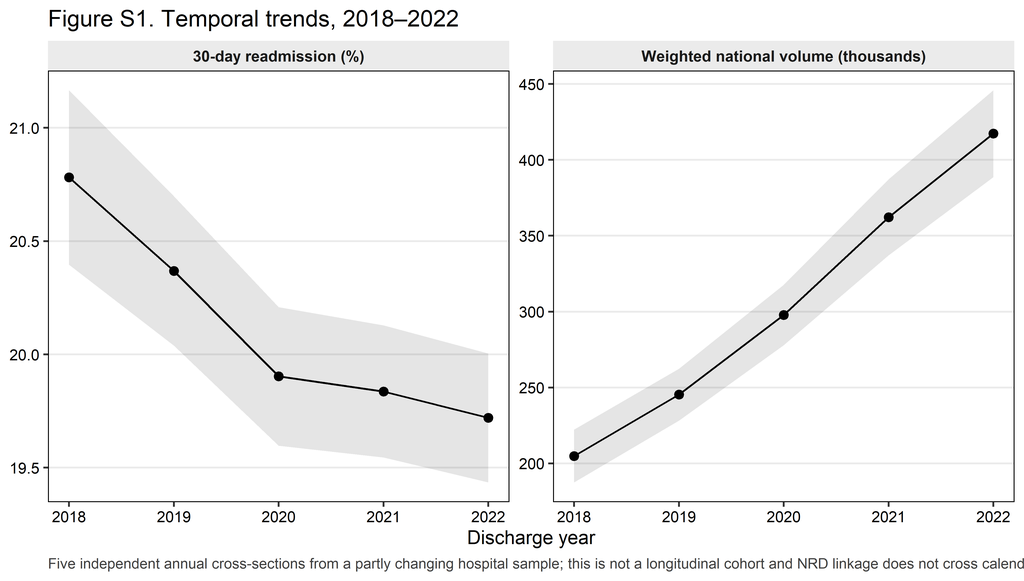

Figure S1. Temporal trends.

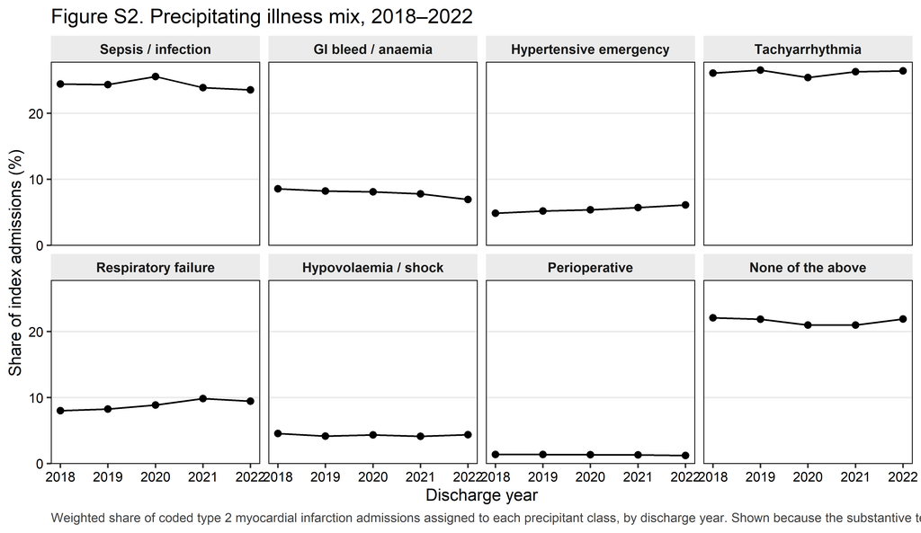

Figure S2. Precipitating illness mix over time.